# hw1

Tariq Anwar

January 20, 2016

Data Set Source: https://github.com/caesar0301/awesome-public-datasets/blob/master/Datasets/titanic.csv.zip

Nature of Data: The dataset contains data about titanic.

It contains infomation about passengers, Gender, Name, Fare , Survived Passengers etc.

There are total 12 features in the dataset and 891 observations.

```r
library(ggplot2)
titanic <- read.csv("C:/Users/tariq/Downloads/titanic.csv")
#Summary
summary(titanic)
```

```
##   PassengerId       Survived          Pclass
##  Min.   :  1.0   Min.   :0.0000   Min.   :1.000
##  1st Qu.:223.5   1st Qu.:0.0000   1st Qu.:2.000
##  Median :446.0   Median :0.0000   Median :3.000
##  Mean   :446.0   Mean   :0.3838   Mean   :2.309
##  3rd Qu.:668.5   3rd Qu.:1.0000   3rd Qu.:3.000
##  Max.   :891.0   Max.   :1.0000   Max.   :3.000
##
##                                     Name         Sex           Age
##  Abbing, Mr. Anthony                  :  1   female:314   Min.   : 0.42
##  Abbott, Mr. Rossmore Edward          :  1   male  :577   1st Qu.:20.12
##  Abbott, Mrs. Stanton (Rosa Hunt)     :  1                Median :28.00
##  Abelson, Mr. Samuel                  :  1                Mean   :29.70
##  Abelson, Mrs. Samuel (Hannah Wizosky):  1                3rd Qu.:38.00
##  Adahl, Mr. Mauritz Nils Martin       :  1                Max.   :80.00
##  (Other)                              :885                NA's   :177
##      SibSp           Parch             Ticket         Fare
##  Min.   :0.000   Min.   :0.0000   1601    :  7   Min.   :  0.00
##  1st Qu.:0.000   1st Qu.:0.0000   347082  :  7   1st Qu.:  7.91
##  Median :0.000   Median :0.0000   CA. 2343:  7   Median : 14.45
##  Mean   :0.523   Mean   :0.3816   3101295 :  6   Mean   : 32.20
##  3rd Qu.:1.000   3rd Qu.:0.0000   347088  :  6   3rd Qu.: 31.00
##  Max.   :8.000   Max.   :6.0000   CA 2144 :  6   Max.   :512.33
##                                   (Other) :852
##          Cabin     Embarked
##             :687    :  2
##  B96 B98    :  4   C:168
##  C23 C25 C27:  4   Q: 77
##  G6         :  4   S:644
##  C22 C26    :  3
##  D          :  3
##  (Other)    :186
```

## Question 1.a

### Total Observations , Total Features

```r
dim(titanic)
```

```
## [1] 891  12
```

```r
#Features of DataSet
names(titanic)
```

```
##  [1] "PassengerId" "Survived"    "Pclass"      "Name"        "Sex"
##  [6] "Age"         "SibSp"       "Parch"       "Ticket"      "Fare"
## [11] "Cabin"       "Embarked"
```

## Question 1.b

### Features Types

```r
type<-list()
for(t in names(titanic))
  type[[t]] <- class(titanic[[t]])

 print(type)
```

```
## $PassengerId
## [1] "integer"
##
## $Survived
## [1] "integer"
##
## $Pclass
## [1] "integer"
##
## $Name
## [1] "factor"
##
## $Sex
## [1] "factor"
##
## $Age
## [1] "numeric"
##
## $SibSp
## [1] "integer"
##
## $Parch
## [1] "integer"
##
## $Ticket
## [1] "factor"
##
## $Fare
## [1] "numeric"
##
## $Cabin
## [1] "factor"
##
## $Embarked
## [1] "factor"
```

## Question1.c

### Summaries of each featured is shown above (i.e summary(titanic))

## Question 1.d

### Univariate Plots for all the numeric data:

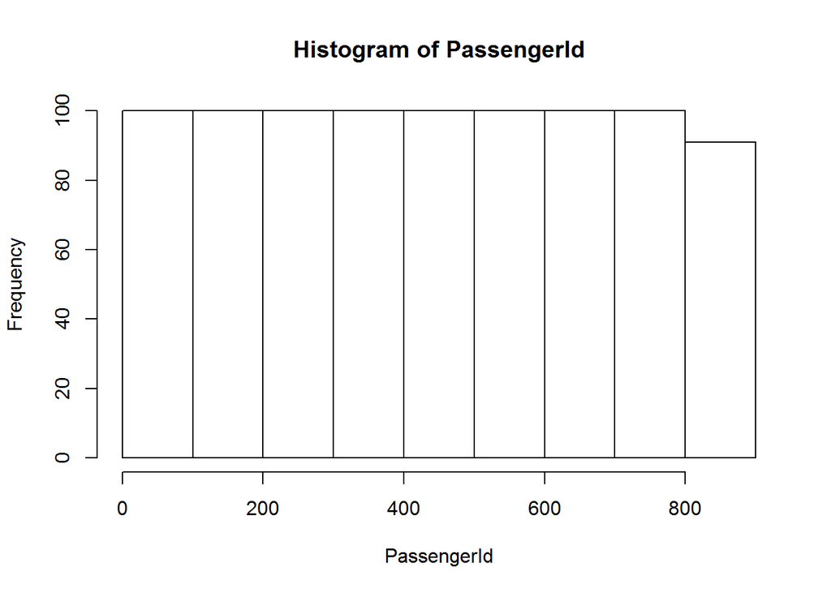

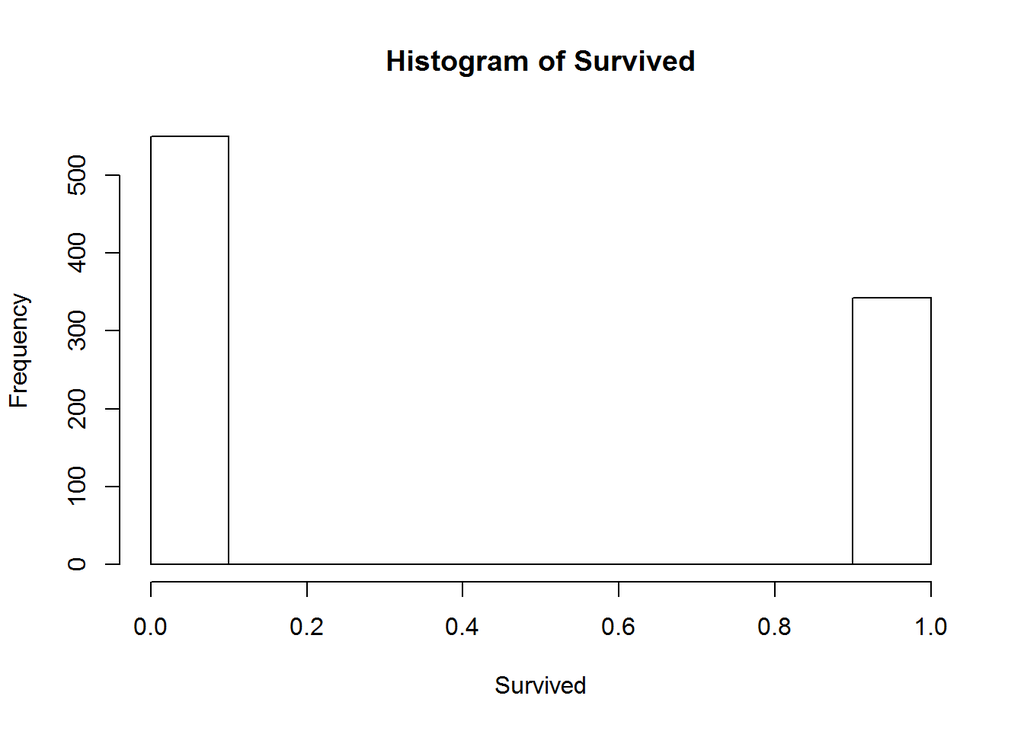

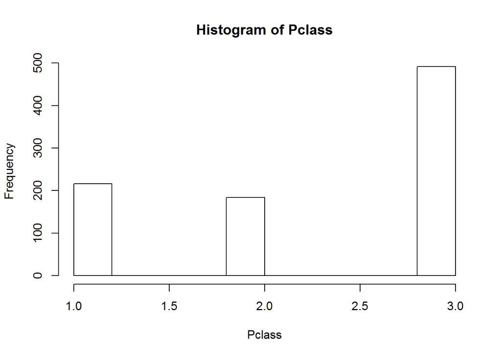

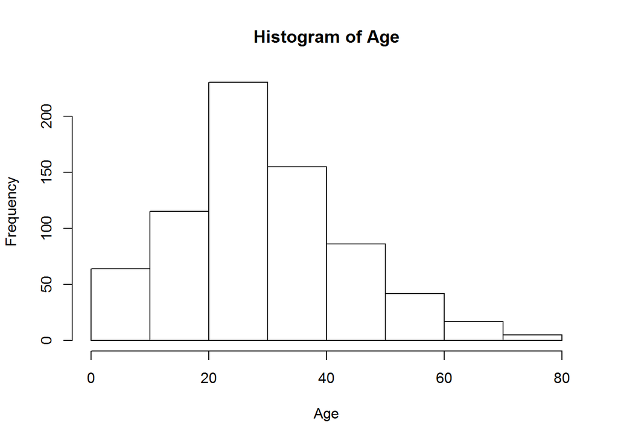

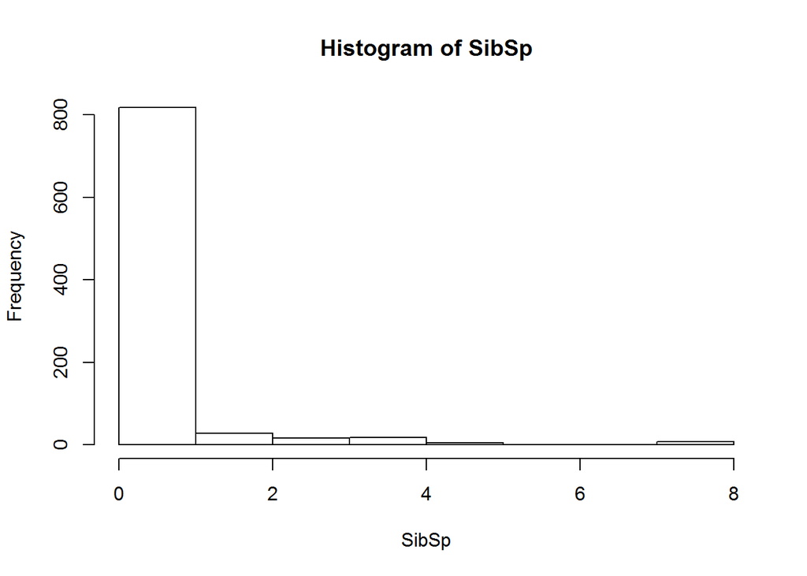

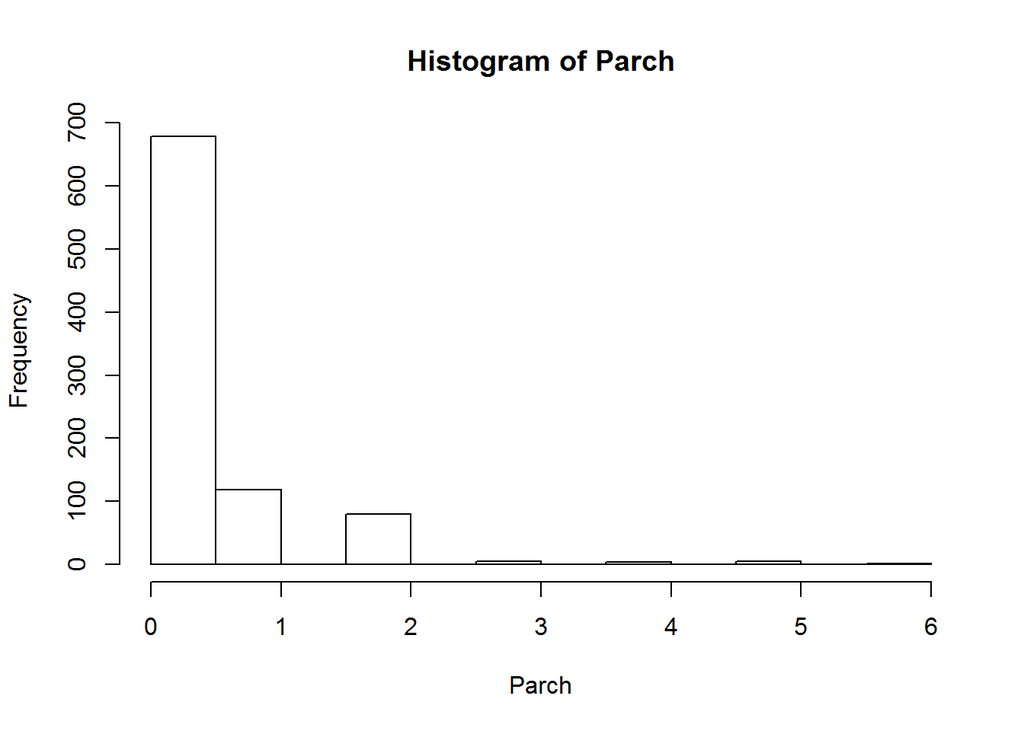

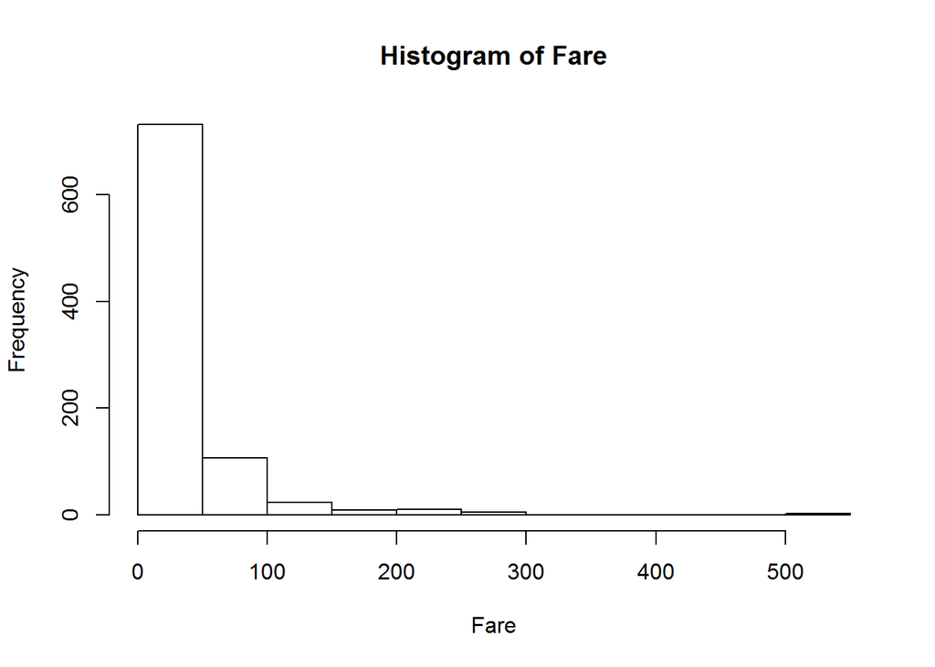

# **Question2**

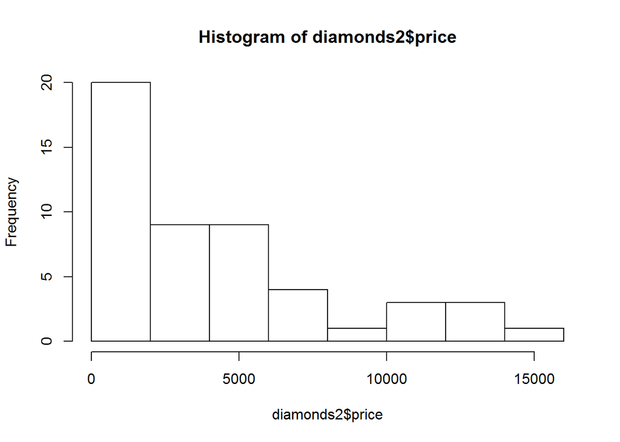

```r
set.seed(123)
index <- sample(1:nrow(diamonds), 50) # try a subset first
diamonds2 <- diamonds[index,]
hist(diamonds2$price)
```

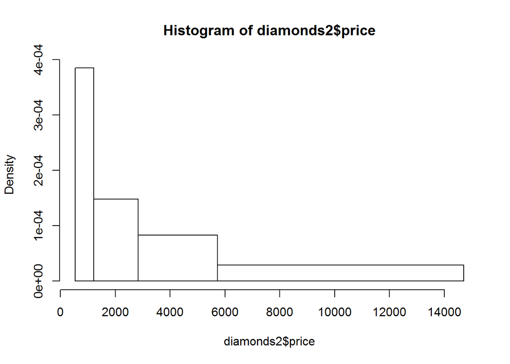

```r
hist(diamonds2$price, breaks=quantile(diamonds2$price))
```

### Question 2.a

We have sample size of 50 diamonds,

The price range is: 537, 14709

we can divide the diamonds in different price group of equal size

with each group having an interval of 2000

Counting the sum of elements in each individual group and storing it in a vector g

```r
g<- numeric(length = 0)
g[1]<- (sum(diamonds2["price"]<=2000))
g[2]<- (sum(diamonds2["price"]<=4000 & diamonds2["price"]>2000))
g[3]<- (sum(diamonds2["price"]<=6000 & diamonds2["price"]>4000))
g[4]<- (sum(diamonds2["price"]<=8000 & diamonds2["price"]>6000))
g[5]<- (sum(diamonds2["price"]<=10000 & diamonds2["price"]>8000))
g[6]<- (sum(diamonds2["price"]<=12000 & diamonds2["price"]>10000))
g[7]<- (sum(diamonds2["price"]<=14000 & diamonds2["price"]>12000))
g[8]<- (sum(diamonds2["price"]<=16000 & diamonds2["price"]>14000))

print(g)
```

```
## [1] 20  9  9  4  1  3  3  1
```

As we can see , vector g contains same number of elements as shown in the given bar graph.

In order to proof the correctness of second histogram , we will calculate each class width, and that can be caculated by finding the quartile of diamonds “price” parameter

```r
quantile(diamonds2$price)
```

```
##       0%      25%      50%      75%     100%
##   537.00  1212.75  2831.00  5724.75 14709.00
```

Now we can calculate height of each box with the following formula: $h(x) = freq/n*(c(i)-c(i+1)$ where h = height : C(i)= lower boundary of interval : c(i+1)= upper boundary of interval : n = total data

```r
f<- numeric(length = 0)
f[1]<- (sum(diamonds2["price"]<=1212.75&diamonds2["price"]>=537 ))
f[2]<- (sum(diamonds2["price"]<=2831 & diamonds2["price"]>1212.75))
f[3]<- (sum(diamonds2["price"]<=5724.75 & diamonds2["price"]>2831))
f[4]<- (sum(diamonds2["price"]<=14709 & diamonds2["price"]>5724.75))

#print(f)

#height of each box
h<- numeric(length = 0)
h[1]<-(f[1])/(50*(1212.75-537))
h[2]<-(f[2])/(50*(2831-1212.75))
h[3]<-(f[3])/(50*(5724.75-2831))
h[4]<-(f[4])/(50*(14709-5724.75))



print(h)
```

```
## [1] 3.847577e-04 1.483084e-04 8.293737e-05 2.893953e-05
```

As we can see the height we calculated manually is almost same as shown in the histogram.

We can cross check the frequency values by below formula

```r
w<-numeric(length = 0)
w[1]<- (h[1] * (1212.75-537))*50
w[2]<-(h[2]*(2831-1212.75))*50
w[3]<-(h[3])*(5724.75-2831)*50
w[4]<-(h[4])*(14709-5724.75)*50
print(w)
```

```
## [1] 13 12 12 13
```

This is the same as the frequency values we calculated above.

If we manually map the height vector and quantile vector it is similar to given histogram.

### Question 2(b):

For the first histogram:

We can count the frequency of first two box , that will give the number of diamonds below 4000

total = freq of 1st box + freq of second box

```
  = 20+9 => 29
```

Proportion of diamonds below 4000 = 0.58

For second histogram:

Proportion of diamonds with price less than 4000 can be calculated as:

$Area of 1st quartile+ Area of second quartile + Area in (4000-2nd quartile boundary)$

```r
val <- (h[1]*(1212.75-537)*50)+(h[2]*(2831-1212.75)*50) + (h[3]*(4000-2831)*50)
```

Proportion of diamonds below 4000 = 0.5969538